# Friedman Rank Sum Test in R

[Nathaniel E. Helwig](http://stat.umn.edu/~helwig) Department of Psychology & School of Statistics University of Minnesota

Copyright © February 17, 2026

# 1 $k \geq 3$ Repeated Measures Location Problem

## 1.1 Overview

For two-way repeated measures layout, we have $N = nk$ observations

- $X_{i1}, \ldots, X_{ik}$ is $i$-th block of data
- $n$ is the number of subjects/blocks
- $k \geq 3$ is the number of treatments

Note: each subject/block participates in $k$ treatments (so $X_{ij}$ and $X_{ij'}$ are dependent)

## 1.2 Block-Location-Shift Model

The *block-location-shift* model assumes that

- $F_j(z - \theta - \beta_i - \tau_j) = F_0(z)$ where $\beta_i$ is the $i$-th block effect and $\tau_j$ is $j$-th treatment effect
- $X_{ij} = \theta + \beta_i + \tau_j + \epsilon_{ij}$ where the $\epsilon_{ij}$ are iid with median zero

## 1.3 Null and Alternative Hypotheses

The null hypothesis assumes that all treatments have the same effect
$$H_{0}: \tau_1 = \tau_2 = \cdots = \tau_k$$
and we only have one reasonable alternative:
$$H_{1}: \tau_j \neq \tau_{j'} \ \mbox{for some} \ j,j'$$

# 2 Methodological Details

## 2.1 Friedman Statistic

Let $r_{ij} \in \{1,\ldots,k\}$ denote the rank of $X_{i1},\ldots,X_{ik}$ within the $i$-th block.

Defining the sum and average of the combined ranks for each group
$$R_{j}= \sum_{i=1}^{n} r_{ij} \qquad \mbox{and} \qquad \bar{R}_j =
R_{j}/n$$
the Friedman test statistic $S$ is defined as
$$S = \frac{12n}{k(k+1)}\sum_{j=1}^{k} \left(\bar{R}_j -
\frac{k+1}{2}\right)^{2}$$
where $\frac{k+1}{2}=(\sum_{i=1}^{n}\sum_{j=1}^{k}r_{ij}/N)$ is average of within-block rankings.

## 2.2 Null Distribution

Under $H_0$ all $M = (k!)^n$ arrangements occur with equal probability.

- $n$ independent subjects and $k$ treatments for each subject
- Given $n$ and $k$, calculate $S$ for all $M$ possible outcomes
- Each outcome has probability $1/ M$ under $H_0$

For $n = 1$ subject with $k = 3$ treatments, there are $M = 6$ arrangements.

[output not shown]

## 2.3 Statistical Inference

### 2.3.1 Exact Test

One-Sided Test (Greater Than)

- $H_{0}: \tau_1 = \tau_2 = \cdots = \tau_k$ versus $H_{1}: \tau_j \neq \tau_{j'} \ \mbox{for some} \ j,j'$
- Reject $H_{0}$ if $S \geq s_{1-\alpha}$ where $P(S>s_{1-\alpha})=\alpha$
- P-Value: $p = \frac{1}{M} \sum_{j=1}^{M} I(S_j \geq S_{\mathrm{obs}})$ where $M = (k!)^n$

Note: this is the only option because larger values of $S$ provide more evidence against $H_0$.

### 2.3.2 Large Sample Approximation

As $n \rightarrow \infty$, we have that $S \sim \chi^{2}_{k-1}$

- $\chi^{2}_{k-1}$ denotes a chi-squared distribution with $k-1$ df
- Reject $H_{0}$ if $S \geq s_{1-\alpha}^*$ where $P(\chi^{2}_{k-1} > s_{1-\alpha}^*) = \alpha$
- P-Value: calculations from the $\chi_{k-1}^2$ distribution

### 2.3.3 Handling Ties

When there are ties, we need to replace $S$ with
$$S^{*} = \frac{12\sum_{j=1}^{k} \left(R_{j} -
\frac{n(k+1)}{2}\right)^{2}}{nk(k+1)-\frac{1}{k-1}\sum_{i=1}^{n}\left[\left(\sum_{j=1}^{g_{i}}
t_{ij}^{3}\right) - k\right] }$$
where

- $g_{i}$ is the number of tied groups in $i$-th block
- $t_{ij}$ is the size of the $j$-th tied group in $i$-th block

# 3 Example

## 3.1 Data and Problem

### 3.1.1 Overview of Problem

Example 7.1 from *Nonparametric Statistical Methods, 3rd Ed*

$n=22$ baseball players participated in a base-running experiment.

Response variable is the time (in seconds) it takes to run from home plate to 2nd base.

Goal was to compare $k=3$ methods to round first base:

- Round out (diamond)
- Narrow angle (asterisk)
- Wide angle (solid)

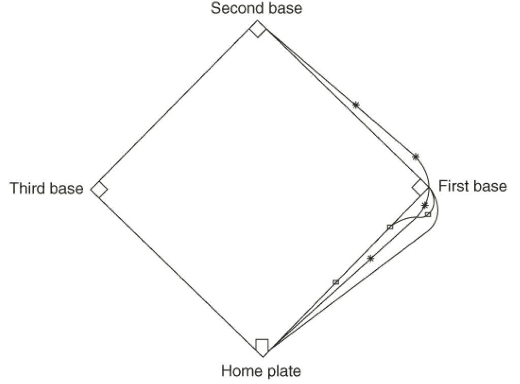

Reproduction of Figure 7.1 from Nonparametric Statistical Methods, 3rd Edition.

### 3.1.2 Data Table

Base running time (in seconds) for each player and method.

| $i$ | Round Out ($j=1$) | Narrow ($j=2$) | Wide ($j=3$) |
| --- | --- | --- | --- |
| 1 | 5.40 | 5.50 | 5.55 |
| 2 | 5.85 | 5.70 | 5.75 |
| 3 | 5.20 | 5.60 | 5.50 |
| 4 | 5.55 | 5.50 | 5.40 |
| 5 | 5.90 | 5.85 | 5.70 |
| 6 | 5.45 | 5.55 | 5.60 |
| 7 | 5.40 | 5.40 | 5.35 |
| 8 | 5.45 | 5.50 | 5.35 |
| 9 | 5.25 | 5.15 | 5.00 |
| 10 | 5.85 | 5.80 | 5.70 |
| 11 | 5.25 | 5.20 | 5.10 |
| 12 | 5.65 | 5.55 | 5.45 |
| 13 | 5.60 | 5.35 | 5.45 |
| 14 | 5.05 | 5.00 | 4.95 |
| 15 | 5.50 | 5.50 | 5.40 |
| 16 | 5.45 | 5.55 | 5.50 |
| 17 | 5.55 | 5.55 | 5.35 |
| 18 | 5.45 | 5.50 | 5.55 |
| 19 | 5.50 | 5.45 | 5.25 |
| 20 | 5.65 | 5.60 | 5.40 |
| 21 | 5.70 | 5.65 | 5.55 |
| 22 | 6.30 | 6.30 | 6.25 |

## 3.2 By Hand

### 3.2.1 Rank Sums

Ranks of running time (in seconds) for each player and method.

| $i$ | Round Out ($j=1$) | Narrow ($j=2$) | Wide ($j=3$) |
| --- | --- | --- | --- |
| 1 | 1.0 | 2.0 | 3.0 |
| 2 | 3.0 | 1.0 | 2.0 |
| 3 | 1.0 | 3.0 | 2.0 |
| 4 | 3.0 | 2.0 | 1.0 |
| 5 | 3.0 | 2.0 | 1.0 |
| 6 | 1.0 | 2.0 | 3.0 |
| 7 | 2.5 | 2.5 | 1.0 |
| 8 | 2.0 | 3.0 | 1.0 |
| 9 | 3.0 | 2.0 | 1.0 |
| 10 | 3.0 | 2.0 | 1.0 |
| 11 | 3.0 | 2.0 | 1.0 |
| 12 | 3.0 | 2.0 | 1.0 |
| 13 | 3.0 | 1.0 | 2.0 |
| 14 | 3.0 | 2.0 | 1.0 |
| 15 | 2.5 | 2.5 | 1.0 |
| 16 | 1.0 | 3.0 | 2.0 |
| 17 | 2.5 | 2.5 | 1.0 |
| 18 | 1.0 | 2.0 | 3.0 |
| 19 | 3.0 | 2.0 | 1.0 |
| 20 | 3.0 | 2.0 | 1.0 |
| 21 | 3.0 | 2.0 | 1.0 |
| 22 | 2.5 | 2.5 | 1.0 |
| $\sum_{i=1}^n r_{ij}$ | 53.0 | 47.0 | 32.0 |

### 3.2.2 Test Statistic

The uncorrected test statistic has the form
$$\begin{split}
S &= 22 \left( (53/22 - 2)^2 + (47/22 - 2)^2 + (32/22 - 2)^2 \right)
\\
&= 10.63636
\end{split}$$

There are ties in blocks $i\in\{7,15,17,22\}$ such that
$$t_{i1}=2 \ \ \mbox{and} \ \ t_{i2}=1$$
because there is one tied group of size 2 and one tied group of size 1 for each block $\Longrightarrow$ $(\sum_{j=1}^{g_{i}} t_{ij}^{3}) - k = (2^3+1^3)-3=6$ for each block.

The corrected test statistic value is
$$\begin{split}
S^* &= \frac{12 \left[ (53-44)^{2} + (47-44)^{2} + (32-44)^{2}
\right]}{22(3)(4) -
(1/2)(6)(4) }\\
&= \frac{(53-44)^{2} + (47-44)^{2} + (32-44)^{2}}{21}\\
&= 11.14286
\end{split}$$

## 3.3 Using R

### 3.3.1 Input Data

Load Data:

```r
widetime <- matrix(c(5.40, 5.50, 5.55,
                     5.85, 5.70, 5.75,
                     5.20, 5.60, 5.50,
                     5.55, 5.50, 5.40,
                     5.90, 5.85, 5.70,
                     5.45, 5.55, 5.60,
                     5.40, 5.40, 5.35,
                     5.45, 5.50, 5.35,
                     5.25, 5.15, 5.00,
                     5.85, 5.80, 5.70,
                     5.25, 5.20, 5.10,
                     5.65, 5.55, 5.45,
                     5.60, 5.35, 5.45,
                     5.05, 5.00, 4.95,
                     5.50, 5.50, 5.40,
                     5.45, 5.55, 5.50,
                     5.55, 5.55, 5.35,
                     5.45, 5.50, 5.55,
                     5.50, 5.45, 5.25,
                     5.65, 5.60, 5.40,
                     5.70, 5.65, 5.55,
                     6.30, 6.30, 6.25),
                   ncol = 3, byrow = TRUE)
```

Long version of data

```r
longtime <- data.frame(time = c(widetime),
                       block = rep(1:nrow(widetime), times = ncol(widetime)),
                       group = rep(1:ncol(widetime), each = nrow(widetime)))
head(longtime)
```

```
##   time block group
## 1 5.40     1     1
## 2 5.85     2     1
## 3 5.20     3     1
## 4 5.55     4     1
## 5 5.90     5     1
## 6 5.45     6     1
```

### 3.3.2 Friedman Rank Sum Test (stats package)

Friedman Rank Sum Test using **stats** package:

```r
friedman.test(widetime)
```

```
##
##  Friedman rank sum test
##
## data:  widetime
## Friedman chi-squared = 11.143, df = 2, p-value = 0.003805
```

### 3.3.3 Friedman Rank Sum Test (nptest package)

Friedman Rank Sum Test using **nptest** package:

```r
library(nptest)
set.seed(1)
mod <- np.aov.test(longtime$time, longtime$group, longtime$block,
                   median.test = TRUE, var.equal = TRUE)
mod
```

```
##
## Friedman ANOVA Test (Equal Variances)
## Number of Groups: 3     Number of Blocks: 22
## H = 10.6364,  p-value = 0.0036
```

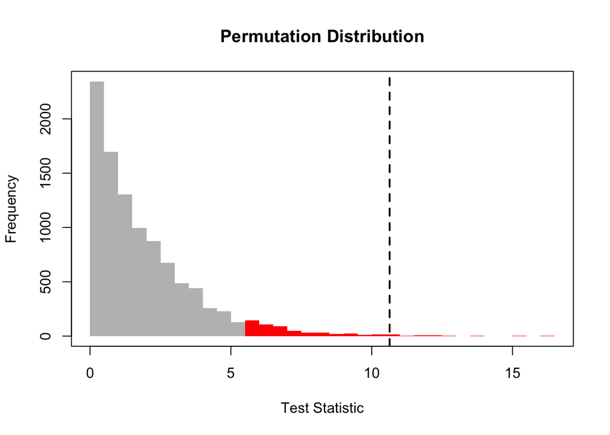

```r
plot(mod)
```

Note: the **nptest** package returns the uncorrected test statistic $S$ (instead of $S^*$).